# Reproducible Research: Peer Assessment 1

## Imputing missing values

There are some missing values in our data set. They can skew the mean and median number of steps we computed earlier. We will attempt to mitigate the effect of missing values by replacing them with the mean of the respective interval across all days.

```r
filled_data <- copy(raw_data)
filled_data[, interval_mean := mean(steps, na.rm = TRUE), by = interval]
filled_data[, steps := as.numeric(steps)]
filled_data[is.na(steps), steps := interval_mean]
filled_data[, interval_mean := NULL]
```

Let’s redraw that histogram of the total steps taken each day and see if it looks different from the first one.

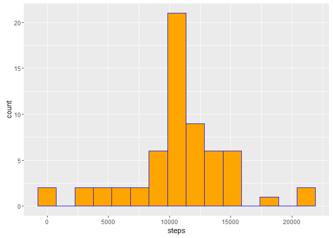

```r
filled_total_per_day <- filled_data[, .(steps = sum(steps)), by = date]
gg <- ggplot(filled_total_per_day, aes(steps))
gg + geom_histogram(bins = 15, color = "blue", fill = "orange")
```

It’s quite different! There are definitely fewer days in the 0 bin. This makes sense because the sum for each day is higher now that we replaced all `NA` intervals with values greater than zero.

## Are there differences in activity patterns between weekdays and weekends?

Using the data set where we imputed missing values, we want to know if the daily activity pattern looks different between weekdays and weekends.

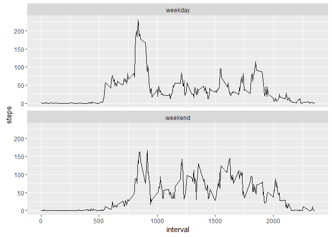

```r
filled_data[, weekday_or_weekend := factor(ifelse(weekdays(fastPOSIXct(date), TRUE) %in% c("Sat", "Sun"), 'weekend', 'weekday'))]
mean_steps_by_interval_weekdays <- filled_data[, .(steps = mean(steps)), by = "interval,weekday_or_weekend"]
gg <- ggplot(mean_steps_by_interval_weekdays, aes(interval, steps))
gg + geom_line() + facet_wrap(~ weekday_or_weekend, 2, 1)
```

It appears that during the weekend the subject walks more throughout the whole day while on weekdays most of the steps are taken in the morning.